# Portfolio analysis

Jeremy Forbes

21/06/2021

## Useful packages

[output not shown]

```
## x lubridate::as.difftime() masks base::as.difftime()
```

## Load portfolio

Currently I have: - NDQ.AX - A200.AX - ASIA.AX

Function to get daily prices

Load all prices into a long dataframe

[output not shown]

```
##     ticker               date                price
##  Length:3048        Min.   :2015-05-26   Min.   :  5.05
##  Class :character   1st Qu.:2018-05-16   1st Qu.: 10.72
##  Mode  :character   Median :2019-06-29   Median : 16.37
##                     Mean   :2019-03-18   Mean   : 38.34
##                     3rd Qu.:2020-06-29   3rd Qu.: 90.67
##                     Max.   :2021-06-29   Max.   :125.23
```

## Plot prices over time

Divide prices by their price at start of 2019

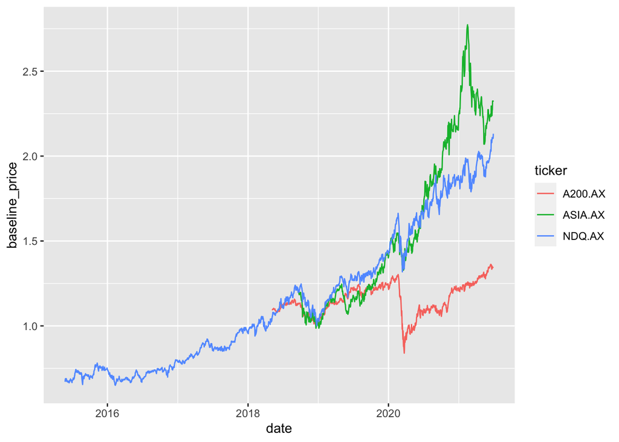

## Plot returns over time

Returns = (P(t+1) - P(t)) / P(t)

```
## # A tibble: 3 x 4
##   ticker     mean     sd yearly_mean
##   <chr>     <dbl>  <dbl>       <dbl>
## 1 A200.AX 0.00155 0.0241        1.08
## 2 ASIA.AX 0.00500 0.0297        1.30
## 3 NDQ.AX  0.00388 0.0242        1.22
```

```
## # A tibble: 3 x 5
##   ticker      n    mean     sd yearly_mean
##   <chr>   <int>   <dbl>  <dbl>       <dbl>
## 1 A200.AX    38 0.00584 0.0548        1.07
## 2 ASIA.AX    34 0.0201  0.0571        1.27
## 3 NDQ.AX     74 0.0156  0.0463        1.21
```

Histograms of weekly returns:

Use qq-plots to see if the distributions are normal

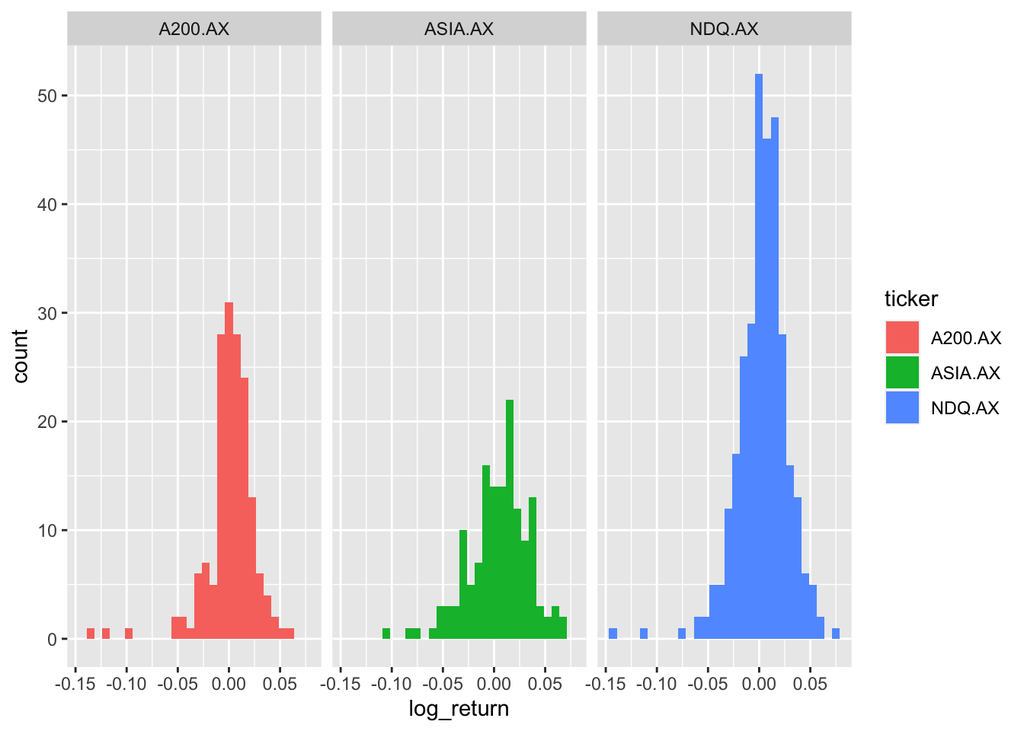

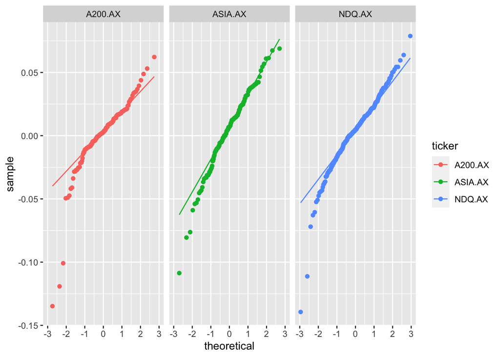

## Determining portfolio split

Let’s look at a series of different splits.

### Create records of historical returns for each portfolio split

Currently daily, change to weekly (or monthly) - based on frequency

```
## [1] "evaluating at month frequency"
```

```
## * seq.0..sum..precision. -> seq.0..sum..precision....1
## * seq.0..sum..precision. -> seq.0..sum..precision....2
```

```
## [1] "evaluating at day frequency"
```

```
## * seq.0..sum..precision. -> seq.0..sum..precision....1
## * seq.0..sum..precision. -> seq.0..sum..precision....2
```

### Choosing a level of risk

Over 5 years, the probability of losing money = 10%

Since
$$\log(P_T/P_0) \approx N(\mu \times T, \sigma^2 \times T)$$

We just want to calculate:
$$\Pr(P_T < P_0) = \Pr(\log(P_{T}/P_0) < 0)$$

#### Monthly prices

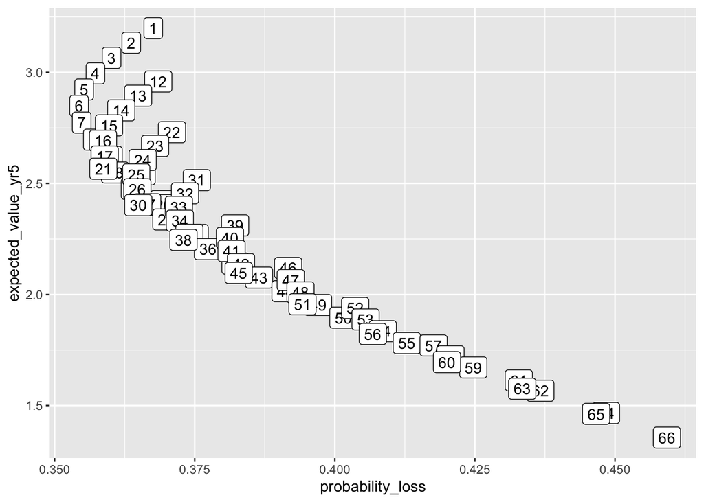

```
## # A tibble: 66 x 10
##    NDQ.AX A200.AX ASIA.AX mean_price_ratio sd_price_ratio mean_log_price_ratio
##     <dbl>   <dbl>   <dbl>            <dbl>          <dbl>                <dbl>
##  1    0         0     1               1.02         0.0569               0.0194
##  2    0.1       0     0.9             1.02         0.0541               0.0190
##  3    0.2       0     0.8             1.02         0.0516               0.0187
##  4    0.3       0     0.7             1.02         0.0495               0.0183
##  5    0.4       0     0.6             1.02         0.0477               0.0179
##  6    0.5       0     0.5             1.02         0.0462               0.0175
##  7    0.6       0     0.4             1.02         0.0453               0.0170
##  8    0.7       0     0.3             1.02         0.0448               0.0165
##  9    0.8       0     0.2             1.02         0.0447               0.0161
## 10    0.9       0     0.1             1.02         0.0452               0.0155
## # … with 56 more rows, and 4 more variables: sd_log_price_ratio <dbl>,
## #   ID <int>, expected_value_yr5 <dbl>, probability_loss <dbl>
```

#### Daily prices

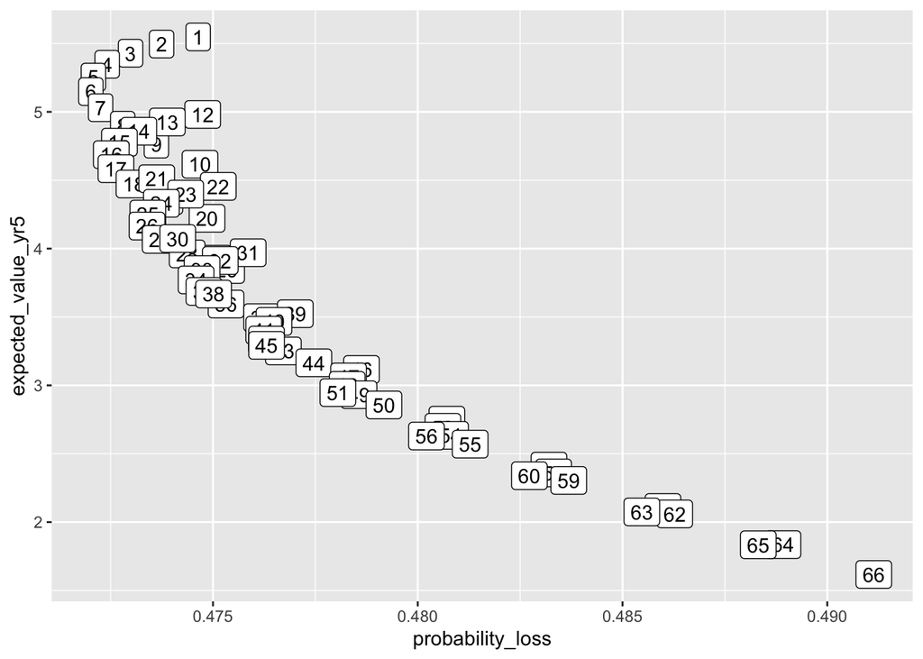

```
## # A tibble: 66 x 10
##    NDQ.AX A200.AX ASIA.AX mean_price_ratio sd_price_ratio mean_log_price_ratio
##     <dbl>   <dbl>   <dbl>            <dbl>          <dbl>                <dbl>
##  1    0         0     1               1.00         0.0147             0.000939
##  2    0.1       0     0.9             1.00         0.0142             0.000934
##  3    0.2       0     0.8             1.00         0.0137             0.000927
##  4    0.3       0     0.7             1.00         0.0133             0.000919
##  5    0.4       0     0.6             1.00         0.0130             0.000909
##  6    0.5       0     0.5             1.00         0.0128             0.000898
##  7    0.6       0     0.4             1.00         0.0127             0.000885
##  8    0.7       0     0.3             1.00         0.0127             0.000871
##  9    0.8       0     0.2             1.00         0.0129             0.000855
## 10    0.9       0     0.1             1.00         0.0132             0.000838
## # … with 56 more rows, and 4 more variables: sd_log_price_ratio <dbl>,
## #   ID <int>, expected_value_yr5 <dbl>, probability_loss <dbl>
```

## Appendix / Old

### Determine the maximum level of risk

How to measure risk? Standard deviation of returns. But how to know what is a high/low value?

If I expect a 5% annual return, translate that to a weekly return. That is the distribution. Then calculate the CDF for returns (using log(returns)) over say a 5 year horizon, then find the value (sd) for which the probability of 0% return over the period is 10%.

I will have to transform the portfolio to log returns so that I can select max average log(return) at that threshold of risk.

## Correlation between prices

```
##          A200.AX
## NDQ.AX 0.4776723
## [1] "Correlation between: NDQ.AX and A200.AX: 0.478"
##          ASIA.AX
## NDQ.AX 0.6292577
## [1] "Correlation between: NDQ.AX and ASIA.AX: 0.629"
##           ASIA.AX
## A200.AX 0.4512807
## [1] "Correlation between: A200.AX and ASIA.AX: 0.451"
```

## Next steps: detect autocorrelation, and find the stationary series